# Excercise Predictive Analysis

Christie Myburgh

18 October 2015

# ABSTRACT

This report descibes a machine learning model developed to predict how “well” people performed barbell lifts. Data from accelerometers on the belt, forearm, arm and dumpbell of 6 participants were used. More information can be obtained from the following website:

http://groupware.les.inf.puc-rio.br/har

Based on the readings the model will predict how well the excercise was performed according to one of the following:

- A - Correct according to specification
- B - Throwing elbows to the front
- C - Lifting dumbbell only halve way
- D - Lowering dumbbell only halve way
- E - Throwing hips to the front.

# 1. DATA

The data used were obtained from the follwoing webistes:

training data set: https://d396qusza40orc.cloudfront.net/predmachlearn/pml-training.csv

test data set: https://d396qusza40orc.cloudfront.net/predmachlearn/pml-testing.csv

The following libraries were used to generate the machine learning model.

```r
#Libraries used in the creation of this document.
library(knitr)

##Set global options - echo is set to TRUE by default so that I do not need to set
# this for every code chunk.
opts_chunk$set(echo = TRUE, results = "hide")

suppressWarnings(suppressMessages(library(caret)))
suppressWarnings(suppressMessages(library(dplyr)))
suppressWarnings(suppressMessages(library(ggplot2)))
suppressWarnings(suppressMessages(library(randomForest)))
library(corrplot)
```

The code below show how the original training and test data sets were loaded and assigned to traindata and testdata dataframes respectively.

```r
traindata <- read.csv("N:/R_Directory/ML/Assignment/MachineLearning/pml-training.csv",
                        sep = ",", header = TRUE)

testdata <- read.csv("N:/R_Directory/ML/Assignment/MachineLearning/pml-testing.csv",
                       sep=",", header=TRUE)
```

# 2.DATA PRE-PROCESSING

The traindata dataset consist of 19622 observations and 160 variables. The testdata dataset consist of 20 observations and the same 160 variables except for the last one. The “classe”" variable is missing from the testdata dataset and is replaced with the “problem_id” variable.

Next I extract predictors from both initial datasets for further analyses. I am discarding the first 6 variables as they are not direct sensor measurements. Two new datasets are created in the process, trainPredictors and testPredictors.

```r
#Extract columns 7 to 159 from the original train and test datasets.
trainPredictors <- traindata[,7:159]

testPredictors <- testdata[,7:159]
```

Next, I convert all remaining predictors to numerical types and replace all missing values with zero.

```r
#Convert all Factor variables to numerical variables.
trainPredictors <- suppressWarnings(data.frame(sapply(trainPredictors, as.numeric)))
testPredictors <- suppressWarnings(data.frame(sapply(testPredictors, as.numeric)))

#Replace all missing values with zero.
trainPredictors[is.na(trainPredictors)] <- 0
testPredictors[is.na(testPredictors)] <- 0
```

I am now in a position to perform some elementary feature selection. I will attmept to reduce the number of predictors as this leads to reduced computational time and complexity.

## 2.1 Near_Zero Variance Predictors.

I start by removing all predictors with near zero variance. Since these predictors have no information they can safely be discarded. The code below is identifying the near zero predictors and are removing them from the train and test data sets. In total the number of predictors were reduced from 153 to 53, a reduction of 100.

```r
#Obtain the indexes of all near_zero predictors.
zeroIdx <- nearZeroVar(trainPredictors)
#Remove near_zero predictors
trainPredictors <- trainPredictors[ ,-zeroIdx]
#Obtain the indexes of all near_zero predictors.
zeroIdx <- nearZeroVar(testPredictors)
#Remove near_zero predictors
testPredictors <- testPredictors[,-zeroIdx]
```

## 2.2 Correlated Predictors.

Next, I will try to identify colinearity between predictors and remove them from the train and test datasets. Again, less predictors result in reduced complexity. The correlation matrix clearly shows that there exist clusters of highly correlated predictors.

```r
#Calculate the correlation between predictors.
correlations <- cor(trainPredictors)
```

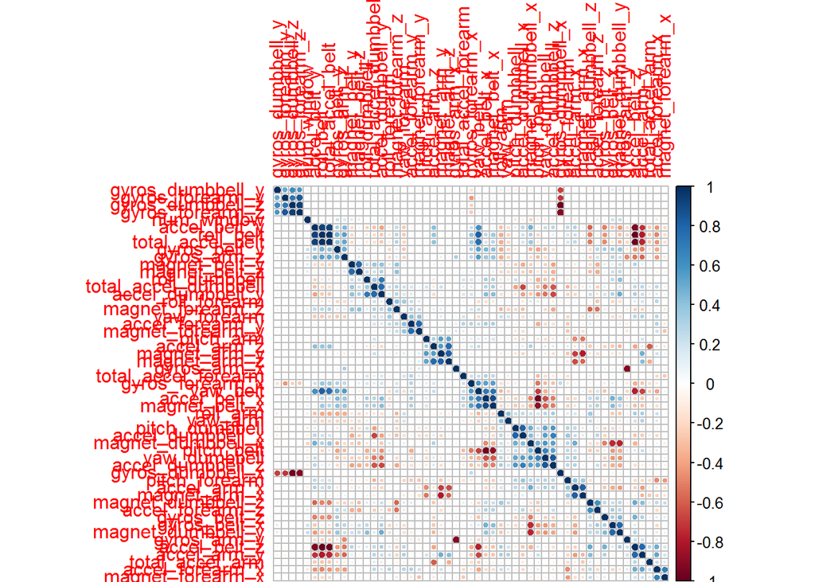

```r
#Visualise the correlation matrix.
corrplot(correlations, order="hclust")
```

```r
#Get column numbers for all predictors above a 0.75 correlation threshold.
highCorr <- findCorrelation(correlations, cutoff=0.75)

#Remove the collinear predictors from the training set.
train_decorr <- trainPredictors[ , -highCorr]

#Remove the collinear predictors from the test training set.
test_decorr <- testPredictors[ , -highCorr]
```

Recalculating the correlation between remaining predictors and replotting them clearly shows that all highly correlated (>0.75) predictors have been removed.

```r
decorr <- cor(train_decorr)
```

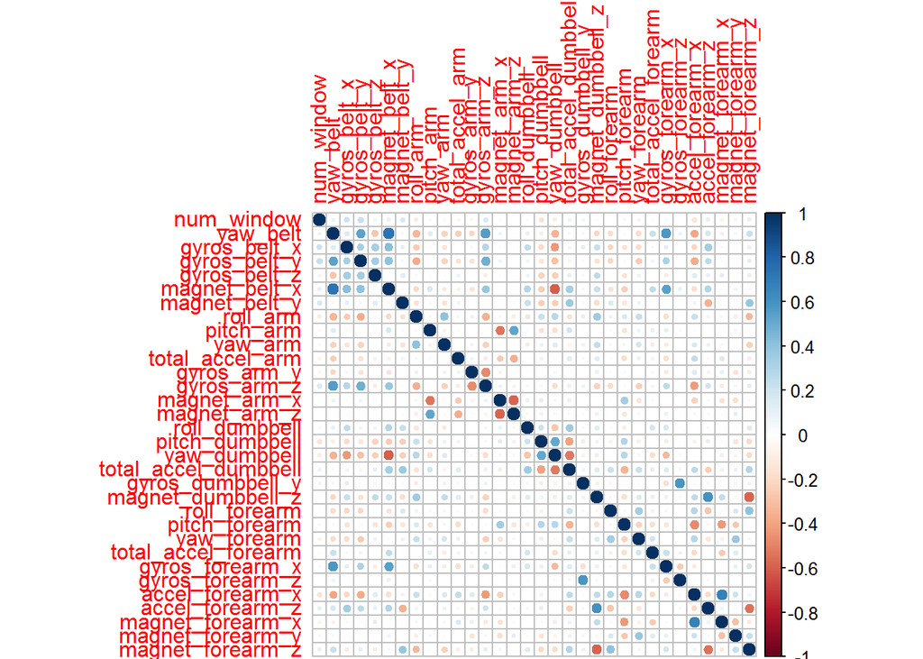

```r
corrplot(decorr)
```

# 3. MODEL CREATION

Now, since the test data that was given do not contain the response or outcome variable “classe”, I need to partition the train dataset into a test and train dataset. This is done on the second line in the code below.

Next, I decided to base my predictive model on a random forest as in general they are very accurate and often form the basis of models that wins competitions like Kaggle. I have used the caret packe train method to create my random forest and used 10 fold Cross Validation repeated 3 times as can be seen in the code below.

```r
set.seed(1234)
#Partition the training data set into a train and test set.
newTrainSet <- createDataPartition(y=traindata$classe, p=0.75, list=FALSE)
#Get the new train data set.
newTrain <- train_decorr[newTrainSet,]
#Get the new test data set.
newTest <- train_decorr[-newTrainSet,]

#Create a factor response variable for the new train set.
fact_class_train <- as.factor(traindata$classe[newTrainSet])
#Create a factor response variable for the new test set.
fact_class_test <- as.factor(traindata$classe[-newTrainSet])
```

As can be seen, Accuracy was use to select the optimal model. The final model used was mtry = 17 with an Accuarcy of 0.998. Since I used 10 Fold Cross Validation in the creation of my model the train function funcion will train on 9/10 of the data and test on the remaining tenth. Therefore the resulting accuracy can be interpreted as in indication of the out-of-sample error as it compares the missing tenth agains the 9 tenths that were used in training.

Therefore an estimate of the out-of-sample error rate is 1 - 0.998 = 0.002.

```r
#Creating predictive model using randomforest with 10 fold Cross Validation,
#repeated 3 times.
rf1 <- train(fact_class_train ~., data=newTrain, method="rf",
             trControl=trainControl(method="repeatedcv", number=10, repeats=3))
```

```r
rf1
```

```
## Random Forest
##
## 14718 samples
##    31 predictor
##     5 classes: 'A', 'B', 'C', 'D', 'E'
##
## No pre-processing
## Resampling: Cross-Validated (10 fold, repeated 3 times)
## Summary of sample sizes: 13244, 13246, 13246, 13247, 13246, 13246, ...
## Resampling results across tuning parameters:
##
##   mtry  Accuracy   Kappa      Accuracy SD  Kappa SD
##    2    0.9956518  0.9944999  0.001697693  0.002147619
##   17    0.9976672  0.9970493  0.001219781  0.001542955
##   32    0.9945644  0.9931248  0.002050454  0.002593748
##
## Accuracy was used to select the optimal model using  the largest value.
## The final value used for the model was mtry = 17.
```

```r
rf1_pred <- predict(rf1, newTest)
```

As can be seen from the confusionMatrix below, the accuracy on my test set is very high => 0.999.

```r
confusionMatrix(rf1_pred, fact_class_test)
```

```
## Confusion Matrix and Statistics
##
##           Reference
## Prediction    A    B    C    D    E
##          A 1394    0    0    0    0
##          B    1  948    2    0    0
##          C    0    1  852    0    0
##          D    0    0    1  804    0
##          E    0    0    0    0  901
##
## Overall Statistics
##
##                Accuracy : 0.999
##                  95% CI : (0.9976, 0.9997)
##     No Information Rate : 0.2845
##     P-Value [Acc > NIR] : < 2.2e-16
##
##                   Kappa : 0.9987
##  Mcnemar's Test P-Value : NA
##
## Statistics by Class:
##
##                      Class: A Class: B Class: C Class: D Class: E
## Sensitivity            0.9993   0.9989   0.9965   1.0000   1.0000
## Specificity            1.0000   0.9992   0.9998   0.9998   1.0000
## Pos Pred Value         1.0000   0.9968   0.9988   0.9988   1.0000
## Neg Pred Value         0.9997   0.9997   0.9993   1.0000   1.0000
## Prevalence             0.2845   0.1935   0.1743   0.1639   0.1837
## Detection Rate         0.2843   0.1933   0.1737   0.1639   0.1837
## Detection Prevalence   0.2843   0.1939   0.1739   0.1642   0.1837
## Balanced Accuracy      0.9996   0.9991   0.9981   0.9999   1.0000
```

# 4. PREDICTIONS FOR TEST CASES

Using the model the following predictions(see below) were obtained for the 20 test cases. All predictions obtained were correct. The 100% accuracy rate of the predictions together with the high accuracy of the model is a bit surprising to me. Usually high accurary of a model reflect some measure of overfitting in my opinion. Maybe the data used here were generated in a highly controlled environment, hence the high accuracy of both the model and predictions.

```r
#Test Case 1
predict(rf1, test_decorr[1,])
```

```
## [1] B
## Levels: A B C D E
```

```r
#Test Case 2
predict(rf1, test_decorr[2,])
```

```
## [1] A
## Levels: A B C D E
```

```r
#Test Case 3
predict(rf1, test_decorr[3,])
```

```
## [1] B
## Levels: A B C D E
```

```r
#Test Case 4
predict(rf1, test_decorr[4,])
```

```
## [1] A
## Levels: A B C D E
```

```r
#Test Case 5
predict(rf1, test_decorr[5,])
```

```
## [1] A
## Levels: A B C D E
```

```r
#Test Case 6
predict(rf1, test_decorr[6,])
```

```
## [1] E
## Levels: A B C D E
```

```r
#Test Case 7
predict(rf1, test_decorr[7,])
```

```
## [1] D
## Levels: A B C D E
```

```r
#Test Case 8
predict(rf1, test_decorr[8,])
```

```
## [1] B
## Levels: A B C D E
```

```r
#Test Case 9
predict(rf1, test_decorr[9,])
```

```
## [1] A
## Levels: A B C D E
```

```r
#Test Case 10
predict(rf1, test_decorr[10,])
```

```
## [1] A
## Levels: A B C D E
```

```r
#Test Case 11
predict(rf1, test_decorr[11,])
```

```
## [1] B
## Levels: A B C D E
```

```r
#Test Case 12
predict(rf1, test_decorr[12,])
```

```
## [1] C
## Levels: A B C D E
```

```r
#Test Case 13
predict(rf1, test_decorr[13,])
```

```
## [1] B
## Levels: A B C D E
```

```r
#Test Case 14
predict(rf1, test_decorr[14,])
```

```
## [1] A
## Levels: A B C D E
```

```r
#Test Case 15
predict(rf1, test_decorr[15,])
```

```
## [1] E
## Levels: A B C D E
```

```r
#Test Case 16
predict(rf1, test_decorr[16,])
```

```
## [1] E
## Levels: A B C D E
```

```r
#Test Case 17
predict(rf1, test_decorr[17,])
```

```
## [1] A
## Levels: A B C D E
```

```r
#Test Case 18
predict(rf1, test_decorr[18,])
```

```
## [1] B
## Levels: A B C D E
```

```r
#Test Case 19
predict(rf1, test_decorr[19,])
```

```
## [1] B
## Levels: A B C D E
```

```r
#Test Case 20
predict(rf1, test_decorr[20,])
```

```
## [1] B
## Levels: A B C D E
```